# Module2 Hui Han Submitted

```python
# updated , Hui Han,
import datashader as ds  # this section from professor Charles Ferrari
import datashader.transfer_functions as tf
import datashader.glyphs
from datashader import reductions
from datashader.core import bypixel
from datashader.utils import lnglat_to_meters as webm, export_image
from datashader.colors import colormap_select, Greys9, viridis, inferno
import copy


from pyproj import Proj, transform
import numpy as np
import pandas as pd
import urllib
import json
import datetime
import colorlover as cl


#import plotly.plotly as py
import plotly.offline as py# no need for plotly web key
import plotly.graph_objs as go
from plotly import tools

from shapely.geometry import Point, Polygon, shape
# In order to get shapley, you'll need to run [pip install shapely.geometry] from your terminal

from functools import partial

from IPython.display import GeoJSON

py.init_notebook_mode()
```

For module 2 we'll be looking at techniques for dealing with big data. In particular binning strategies and the datashader library (which possibly proves we'll never need to bin large data for visualization ever again.)

To demonstrate these concepts we'll be looking at the PLUTO dataset put out by New York City's department of city planning. PLUTO contains data about every tax lot in New York City.

PLUTO data can be downloaded from [here](https://www1.nyc.gov/site/planning/data-maps/open-data/dwn-pluto-mappluto.page). Unzip them to the same directory as this notebook, and you should be able to read them in using this (or very similar) code. Also take note of the data dictionary, it'll come in handy for this assignment.

```python
pwd
```

```
'C:\\Users\\graci\\Documents\\608 HH\\608 Module2 HH'
```

```python
# this section from professor Charles Ferrari
ny = pd.read_csv('pluto_18v2.csv')
#ny = pd.read_csv('nyc_pluto_18v2_csv/pluto_18v2.csv')

# Getting rid of some outliers
#ny = ny[(ny['YearBuilt'] > 1850) & (ny['YearBuilt'] < 2020) & (ny['NumFloors'] != 0)]  # no caps
ny = ny[(ny['yearbuilt'] > 1850) & (ny['yearbuilt'] < 2020) & (ny['numfloors'] != 0)]
ny.head()
```

|  | borough | block | lot | cd | ct2010 | cb2010 | schooldist | council | zipcode | firecomp | ... | pfirm15_flag | rpaddate | dcasdate | zoningdate | landmkdate | basempdate | masdate | polidate | edesigdate | geom |
| --- | --- | --- | --- | --- | --- | --- | --- | --- | --- | --- | --- | --- | --- | --- | --- | --- | --- | --- | --- | --- | --- |
| 0 | QN | 6087 | 10 | 411.0 | 1099.00 | 1010.0 | 26.0 | 19.0 | 11361.0 | E320 | ... | NaN | 12/06/2018 | 12/20/2018 | 12/21/18 | 12/20/2018 | 12/21/2018 | NaN | NaN | 12/20/2018 | 0106000020E61000000100000001030000000100000005... |
| 1 | QN | 6092 | 31 | 411.0 | 1097.00 | 3003.0 | 26.0 | 19.0 | 11361.0 | E320 | ... | NaN | 12/06/2018 | 12/20/2018 | 12/21/18 | 12/20/2018 | 12/21/2018 | NaN | NaN | 12/20/2018 | 0106000020E61000000100000001030000000100000005... |
| 2 | SI | 2450 | 7501 | 502.0 | 277.02 | 3006.0 | 31.0 | 51.0 | 10314.0 | L087 | ... | NaN | 12/06/2018 | 12/20/2018 | 12/21/18 | 12/20/2018 | 12/21/2018 | NaN | NaN | 12/20/2018 | 0106000020E6100000030000000103000000010000001E... |
| 3 | BK | 6769 | 94 | 314.0 | 546.00 | 1001.0 | 22.0 | 48.0 | 11210.0 | E276 | ... | NaN | 12/06/2018 | 12/20/2018 | 12/21/18 | 12/20/2018 | 12/21/2018 | NaN | NaN | 12/20/2018 | 0106000020E61000000100000001030000000100000005... |
| 4 | BK | 6770 | 85 | 314.0 | 546.00 | 1000.0 | 22.0 | 48.0 | 11210.0 | E276 | ... | NaN | 12/06/2018 | 12/20/2018 | 12/21/18 | 12/20/2018 | 12/21/2018 | NaN | NaN | 12/20/2018 | 0106000020E61000000100000001030000000100000005... |

5 rows × 97 columns

I'll also do some prep for the geographic component of this data, which we'll be relying on for datashader.

You're not required to know how I'm retrieving the lattitude and longitude here, but for those interested: this dataset uses a flat x-y projection (assuming for a small enough area that the world is flat for easier calculations), and this needs to be projected back to traditional lattitude and longitude.

```python
# this section from professor Charles Ferrari
wgs84 = Proj("+proj=longlat +ellps=GRS80 +datum=NAD83 +no_defs")
nyli = Proj("+proj=lcc +lat_1=40.66666666666666 +lat_2=41.03333333333333 +lat_0=40.16666666666666 +lon_0=-74 +x_0=300000 +y_0=0 +ellps=GRS80 +datum=NAD83 +to_meter=0.3048006096012192 +no_defs")
ny['xcoord'] = 0.3048*ny['xcoord']
ny['ycoord'] = 0.3048*ny['ycoord']
ny['lon'], ny['lat'] = transform(nyli, wgs84, ny['xcoord'].values, ny['ycoord'].values)

ny = ny[(ny['lon'] < -60) & (ny['lon'] > -100) & (ny['lat'] < 60) & (ny['lat'] > 20)]

#Defining some helper functions for DataShader
background = "black"
export = partial(export_image, background = background, export_path="export")
cm = partial(colormap_select, reverse=(background!="black"))
ny.head()
```

|  | borough | block | lot | cd | ct2010 | cb2010 | schooldist | council | zipcode | firecomp | ... | dcasdate | zoningdate | landmkdate | basempdate | masdate | polidate | edesigdate | geom | lon | lat |
| --- | --- | --- | --- | --- | --- | --- | --- | --- | --- | --- | --- | --- | --- | --- | --- | --- | --- | --- | --- | --- | --- |
| 0 | QN | 6087 | 10 | 411.0 | 1099.00 | 1010.0 | 26.0 | 19.0 | 11361.0 | E320 | ... | 12/20/2018 | 12/21/18 | 12/20/2018 | 12/21/2018 | NaN | NaN | 12/20/2018 | 0106000020E61000000100000001030000000100000005... | -73.783232 | 40.769324 |
| 1 | QN | 6092 | 31 | 411.0 | 1097.00 | 3003.0 | 26.0 | 19.0 | 11361.0 | E320 | ... | 12/20/2018 | 12/21/18 | 12/20/2018 | 12/21/2018 | NaN | NaN | 12/20/2018 | 0106000020E61000000100000001030000000100000005... | -73.781451 | 40.768785 |
| 2 | SI | 2450 | 7501 | 502.0 | 277.02 | 3006.0 | 31.0 | 51.0 | 10314.0 | L087 | ... | 12/20/2018 | 12/21/18 | 12/20/2018 | 12/21/2018 | NaN | NaN | 12/20/2018 | 0106000020E6100000030000000103000000010000001E... | -74.163050 | 40.578659 |
| 3 | BK | 6769 | 94 | 314.0 | 546.00 | 1001.0 | 22.0 | 48.0 | 11210.0 | E276 | ... | 12/20/2018 | 12/21/18 | 12/20/2018 | 12/21/2018 | NaN | NaN | 12/20/2018 | 0106000020E61000000100000001030000000100000005... | -73.951808 | 40.613547 |
| 4 | BK | 6770 | 85 | 314.0 | 546.00 | 1000.0 | 22.0 | 48.0 | 11210.0 | E276 | ... | 12/20/2018 | 12/21/18 | 12/20/2018 | 12/21/2018 | NaN | NaN | 12/20/2018 | 0106000020E61000000100000001030000000100000005... | -73.950775 | 40.613063 |

5 rows × 99 columns

## Part 1: Binning and Aggregation

Binning is a common strategy for visualizing large datasets. Binning is inherent to a few types of visualizations, such as histograms and [2D histograms](https://plot.ly/python/2D-Histogram/) (also check out their close relatives: [2D density plots](https://plot.ly/python/2d-density-plots/) and the more general form: [heatmaps](https://plot.ly/python/heatmaps/).

While these visualization types explicitly include binning, any type of visualization used with aggregated data can be looked at in the same way. For example, lets say we wanted to look at building construction over time. This would be best viewed as a line graph, but we can still think of our results as being binned by year:

```python
# this section from professor Charles Ferrari
trace = go.Scatter(
    # I'm choosing BBL here because I know it's a unique key.
    x = ny.groupby('yearbuilt').count()['bbl'].index,
    y = ny.groupby('yearbuilt').count()['bbl']
)

layout = go.Layout(
    xaxis = dict(title = 'Year Built'),
    yaxis = dict(title = 'Number of Lots Built')
)

fig = go.Figure(data = [trace], layout = layout)

py.iplot(fig, filename = 'ny-year-built')
```

[interactive chart not shown]

Something looks off... You're going to have to deal with this imperfect data to answer this first question.

But first: some notes on pandas. Pandas dataframes are a different beast than R dataframes, here are some tips to help you get up to speed:

Hello all, here are some pandas tips to help you guys through this homework:

[Indexing and Selecting](https://pandas.pydata.org/pandas-docs/stable/indexing.html): .loc and .iloc are the analogs for base R subsetting, or filter() in dplyr

[Group By](https://pandas.pydata.org/pandas-docs/stable/groupby.html): This is the pandas analog to group_by() and the appended function the analog to summarize(). Try out a few examples of this, and display the results in Jupyter. Take note of what's happening to the indexes, you'll notice that they'll become hierarchical. I personally find this more of a burden than a help, and this sort of hierarchical indexing leads to a fundamentally different experience compared to R dataframes. Once you perform an aggregation, try running the resulting hierarchical datafrome through a [reset_index()](https://pandas.pydata.org/pandas-docs/stable/generated/pandas.DataFrame.reset_index.html).

[Reset_index](https://pandas.pydata.org/pandas-docs/stable/generated/pandas.DataFrame.reset_index.html): I personally find the hierarchical indexes more of a burden than a help, and this sort of hierarchical indexing leads to a fundamentally different experience compared to R dataframes. reset_index() is a way of restoring a dataframe to a flatter index style. Grouping is where you'll notice it the most, but it's also useful when you filter data, and in a few other split-apply-combine workflows. With pandas indexes are more meaningful, so use this if you start getting unexpected results.

Indexes are more important in Pandas than in R. If you delve deeper into the using python for data science, you'll begin to see the benefits in many places (despite the personal gripes I highlighted above.) One place these indexes come in handy is with time series data. The pandas docs have a [huge section](http://pandas.pydata.org/pandas-docs/stable/timeseries.html) on datetime indexing. In particular, check out [resample](https://pandas.pydata.org/pandas-docs/stable/generated/pandas.DataFrame.resample.html), which provides time series specific aggregation.

[Merging, joining, and concatenation](https://pandas.pydata.org/pandas-docs/stable/merging.html): There's some overlap between these different types of merges, so use this as your guide. Concat is a single function that replaces cbind and rbind in R, and the results are driven by the indexes. Read through these examples to get a feel on how these are performed, but you will have to manage your indexes when you're using these functions. Merges are fairly similar to merges in R, similarly mapping to SQL joins.

Apply: This is explained in the "group by" section linked above. These are your analogs to the plyr library in R. Take note of the lambda syntax used here, these are anonymous functions in python. Rather than predefining a custom function, you can just define it inline using lambda.

Browse through the other sections for some other specifics, in particular reshaping and categorical data (pandas' answer to factors.) Pandas can take a while to get used to, but it is a pretty strong framework that makes more advanced functions easier once you get used to it. Rolling functions for example follow logically from the apply workflow (and led to the best google results ever when I first tried to find this out and googled "pandas rolling")

Google Wes Mckinney's book "Python for Data Analysis," which is a cookbook style intro to pandas. It's an O'Reilly book that should be pretty available out there.

### Question

After a few building collapses, the City of New York is going to begin investigating older buildings for safety. The city is particularly worried about buildings that were unusually tall when they were built, since best-practices for safety hadn’t yet been determined. Create a graph that shows how many buildings of a certain number of floors were built in each year (note: you may want to use a log scale for the number of buildings). Find a strategy to bin buildings (It should be clear 20-29-story buildings, 30-39-story buildings, and 40-49-story buildings were first built in large numbers, but does it make sense to continue in this way as you get taller?)

### Answer to Q1-Binning Aggregation:

first, I followed the example of Dr. Ferrari, and changed it to my need. I am looking at the maximum numbers of floors that have been built by year. Although it does not answer entirely the question asked by professor, it gave me a start.

```python
trace = go.Scatter(
     x = ny.groupby(['yearbuilt']).max()['numfloors'].index,
     y = ny.groupby(['yearbuilt']).max()['numfloors']
)

layout = go.Layout(
    xaxis = dict(title = 'Year Built'),
    yaxis = dict(title = 'Maximum Number Of FLoors Built this Year')
)

fig = go.Figure(data = [trace], layout = layout)

py.iplot(fig, filename = 'MaxNumFloorThisYear')
```

[interactive chart not shown]

judging from above figure, we can see that before 1990, there are almost no high rise buildings consructed as all. Then, in 1920 there is a very big peak of high rise buildings contructed (the actual numbers in 1920 is 205). Then, the next wave happened in 1932 to 1940. So, from above, we feel that due to the aging effect of these buildings as well as abundancy of them, these years are what we should really focus on.

Then, I tried to make sub-plots (6 of the bar chart plots), so that the sub-categories will be FloorBins, the X Axis will be YearBins, and the Y axis will be numbers of Buildings constructed.

```python
#  2 bins, floors of Building, Year
ny=df

bins1 = [0, 10, 20, 30, 40, 50, 60, 120]
labels1 = ['0-10','11-19','20-30','30-39','40-49','50-59','60-120']
ny['flbinned'] = pd.cut(ny['numfloors'], bins=bins1, labels = labels1)
ny.head()
```

|  | borough | block | lot | cd | ct2010 | cb2010 | schooldist | council | zipcode | firecomp | ... | zoningdate | landmkdate | basempdate | masdate | polidate | edesigdate | geom | lon | lat | flbinned |
| --- | --- | --- | --- | --- | --- | --- | --- | --- | --- | --- | --- | --- | --- | --- | --- | --- | --- | --- | --- | --- | --- |
| 0 | QN | 6087 | 10 | 411.0 | 1099.00 | 1010.0 | 26.0 | 19.0 | 11361.0 | E320 | ... | 12/21/18 | 12/20/2018 | 12/21/2018 | NaN | NaN | 12/20/2018 | 0106000020E61000000100000001030000000100000005... | -73.783232 | 40.769324 | 0-10 |
| 1 | QN | 6092 | 31 | 411.0 | 1097.00 | 3003.0 | 26.0 | 19.0 | 11361.0 | E320 | ... | 12/21/18 | 12/20/2018 | 12/21/2018 | NaN | NaN | 12/20/2018 | 0106000020E61000000100000001030000000100000005... | -73.781451 | 40.768785 | 0-10 |
| 2 | SI | 2450 | 7501 | 502.0 | 277.02 | 3006.0 | 31.0 | 51.0 | 10314.0 | L087 | ... | 12/21/18 | 12/20/2018 | 12/21/2018 | NaN | NaN | 12/20/2018 | 0106000020E6100000030000000103000000010000001E... | -74.163050 | 40.578659 | 0-10 |
| 3 | BK | 6769 | 94 | 314.0 | 546.00 | 1001.0 | 22.0 | 48.0 | 11210.0 | E276 | ... | 12/21/18 | 12/20/2018 | 12/21/2018 | NaN | NaN | 12/20/2018 | 0106000020E61000000100000001030000000100000005... | -73.951808 | 40.613547 | 0-10 |
| 4 | BK | 6770 | 85 | 314.0 | 546.00 | 1000.0 | 22.0 | 48.0 | 11210.0 | E276 | ... | 12/21/18 | 12/20/2018 | 12/21/2018 | NaN | NaN | 12/20/2018 | 0106000020E61000000100000001030000000100000005... | -73.950775 | 40.613063 | 0-10 |

5 rows × 100 columns

```python
#  this is the year bins, focusing on the years that we found peaks of construction.

bins2 = [1851, 1910, 1920, 1940,1980, 2000, 2018]
labels2 = ['1851-1910','1911-1919','1920-1939','1940-1979','1980-1999','2000-2018']
ny['yearbinned'] = pd.cut(ny['yearbuilt'], bins=bins2, labels = labels2)

data = ny.groupby(['yearbinned', 'flbinned']).size().reset_index(name='count')
data.head()
```

|  | yearbinned | flbinned | count |
| --- | --- | --- | --- |
| 0 | 1851-1910 | 0-10 | 117865 |
| 1 | 1851-1910 | 11-19 | 443 |
| 2 | 1851-1910 | 20-30 | 21 |
| 3 | 1851-1910 | 30-39 | 1 |
| 4 | 1851-1910 | 40-49 | 1 |

```python
#  Data preperation for the subplots, append the x goether (year bins),
# to plotting the numbers of buildings

#['1851-1910','1911-1919','1920-1939','1940-1979','1980-1999','2000-2018']
x0 = data.loc[data['yearbinned']=='1851-1910']
x1 = data.loc[data['yearbinned']=='1911-1919']
x2 = data.loc[data['yearbinned']=='1920-1939']
x3 = data.loc[data['yearbinned']=='1940-1979']
x4 = data.loc[data['yearbinned']=='1980-1999']
x5 = data.loc[data['yearbinned']=='2000-2018']
```

```python
##

trace0 = go.Bar(
x = x0.iloc[:,1:2].values,
y = x0.iloc[:,3:4].values,
name = "1851-1910"
)
trace1 = go.Bar(
x = x1.iloc[:,1:2].values,
y = x1.iloc[:,3:4].values,
name = "1911-1919"
)

trace2 = go.Bar(
x = x2.iloc[:,1:2].values,
y = x2.iloc[:,3:4].values,
name = "1920-1939"
)
trace3 = go.Bar(
# I'm choosing BBL here because I know it's a unique key.
x = x3.iloc[:,1:2].values,
y = x3.iloc[:,3:4].values,
name = "1940-1979"
)
trace4 = go.Bar(
# I'm choosing BBL here because I know it's a unique key.
x = x4.iloc[:,1:2].values,
y = x4.iloc[:,3:4].values,
name = "1980-1999"
)
trace5 = go.Bar(
# I'm choosing BBL here because I know it's a unique key.
x = x5.iloc[:,1:2].values,
y = x5.iloc[:,3:4].values,
name = "2000-2018"
)
```

```python
# added from Ferrari
layout = go.Layout(
    xaxis = dict(title = 'YearBin n FLoorHeightBin'),
    yaxis = dict(title = 'Counts of Buidlings')
)
```

```python
## attempting to make 6 sub-plots

fig = tools.make_subplots(rows=1, cols=6, shared_yaxes=True)

fig.append_trace(trace0, 1, 1)
fig.append_trace(trace1, 1, 2)
fig.append_trace(trace2, 1, 3)
fig.append_trace(trace3, 1, 4)
fig.append_trace(trace4, 1, 5)
fig.append_trace(trace5, 1, 6)
```

```
This is the format of your plot grid:
[ (1,1) x1,y1 ]  [ (1,2) x2,y1 ]  [ (1,3) x3,y1 ]  [ (1,4) x4,y1 ]  [ (1,5) x5,y1 ]  [ (1,6) x6,y1 ]
```

```python
fig['layout'].update(height=600, width=800,showlegend=False,
    title='Number of buildings built per bin of years')
```

```
Layout({
    'height': 600,
    'showlegend': False,
    'title': {'text': 'Number of buildings built per bin of years'},
    'width': 800,
    'xaxis': {'anchor': 'y', 'domain': [0.0, 0.1388888888888889]},
    'xaxis2': {'anchor': 'free', 'domain': [0.17222222222222222, 0.3111111111111111], 'position': 0.0},
    'xaxis3': {'anchor': 'free', 'domain': [0.34444444444444444, 0.48333333333333334], 'position': 0.0},
    'xaxis4': {'anchor': 'free', 'domain': [0.5166666666666667, 0.6555555555555557], 'position': 0.0},
    'xaxis5': {'anchor': 'free', 'domain': [0.6888888888888889, 0.8277777777777777], 'position': 0.0},
    'xaxis6': {'anchor': 'free', 'domain': [0.861111111111111, 1.0], 'position': 0.0},
    'yaxis': {'anchor': 'x', 'domain': [0.0, 1.0]}
})
```

```python
# trying to debug

fig.print_grid
```

[output not shown]

[output cut: 32 more lines]

```
              'xaxis': 'x6',
              'y': array([], shape=(7, 0), dtype=float64),
              'yaxis': 'y'}],
    'layout': {'height': 600,
               'showlegend': False,
               'title': {'text': 'Number of buildings built per bin of years'},
               'width': 800,
               'xaxis': {'anchor': 'y', 'domain': [0.0, 0.1388888888888889]},
               'xaxis2': {'anchor': 'free', 'domain': [0.17222222222222222, 0.3111111111111111], 'position': 0.0},
               'xaxis3': {'anchor': 'free', 'domain': [0.34444444444444444, 0.48333333333333334], 'position': 0.0},
               'xaxis4': {'anchor': 'free', 'domain': [0.5166666666666667, 0.6555555555555557], 'position': 0.0},
               'xaxis5': {'anchor': 'free', 'domain': [0.6888888888888889, 0.8277777777777777], 'position': 0.0},
               'xaxis6': {'anchor': 'free', 'domain': [0.861111111111111, 1.0], 'position': 0.0},
               'yaxis': {'anchor': 'x', 'domain': [0.0, 1.0]}}
})>
```

```python
# omitted, professor's example
```

```python
# omitted, professor's example
```

That's technically just a scatterplot, but the points are smartly placed and colored to mimic what one gets in a heatmap. Based on the pixel size, it will either display individual points, or will color the points of denser regions.

```python
# omitted, professor's example
```

Unfortunately, Datashader doesn't have the best documentation. Browse through the examples from their [github repo](https://github.com/bokeh/datashader/tree/master/examples). I would focus on the [visualization pipeline](https://anaconda.org/jbednar/pipeline/notebook) and the [US Census](https://anaconda.org/jbednar/census/notebook) Example for the question below. [This talk](https://www.youtube.com/watch?v=6m3CFbKmK_c) also provides a nice background for datashader. Feel free to use my samples as templates as well when you work on this problem.

### Question

You work for a real estate developer and are researching underbuilt areas of the city. After looking in the [Pluto data dictionary](https://www1.nyc.gov/assets/planning/download/pdf/data-maps/open-data/pluto_datadictionary.pdf?v=17v1_1), you've discovered that all tax assessments consist of two parts: The assessment of the land and assessment of the structure. You reason that there should be a correlation between these two values: more valuable land will have more valuable structures on them (more valuable in this case refers not just to a mansion vs a bungalow, but an apartment tower vs a single family home). Deviations from the norm could represent underbuilt or overbuilt areas of the city. You also recently read a really cool blog post about [bivariate choropleth maps](http://www.joshuastevens.net/cartography/make-a-bivariate-choropleth-map/), and think the technique could be used for this problem.

Datashader is really cool, but it's not that great at labeling your visualization. Don't worry about providing a legend, but provide a quick explanation as to which areas of the city are overbuilt, which areas are underbuilt, and which areas are built in a way that's properly correlated with their land value.

## Answer to Q2-Datashader

```python
assessNY =ny[['assesstot', 'assessland','lon','lat']].copy()

# Building Value is based on total value and land value
assessNY['assbuilding'] = assessNY['assesstot']-assessNY['assessland']

print (assessNY['assbuilding'].describe())
```

```
count    8.124310e+05
mean     3.514558e+05
std      6.765252e+06
min      0.000000e+00
25%      1.548000e+04
50%      2.184000e+04
75%      3.381300e+04
max      3.746639e+09
Name: assbuilding, dtype: float64
```

```python
assessNY.head()
```

[output not shown]

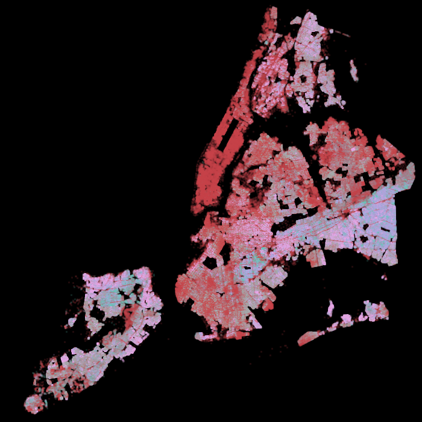

```python
# for LandValueAssessement and Building Value Assessment,
# three bins are used as:Low, Medium and High

labels = ['L', 'M', 'H']
assessNY['asslandbins'] =  pd.qcut(assessNY.assessland, 3, labels=labels)
assessNY['assbuldbins'] =  pd.qcut(assessNY.assbuilding, 3, labels=labels)
assessNY['Comb'] = assessNY.asslandbins.astype(str) + '_' + assessNY.assbuldbins.astype(str)

assessNY.Comb = assessNY.Comb.astype('category')
# color codes are gradient from blue (underBuilt), to light pink, dark pink, to dark red (OverBuilt)
colors = {'L_L': '#e8a8e8', 'L_M': '#a4acac', 'L_H': '#c85a5a',
          'M_L': '#b0a5df', 'M_M': '#ad9ea5', 'M_H': '#c85356',
          'H_L': '#64ccbe', 'H_M': '#a27f8c', 'H_H': '#c74249'}

NewYorkCity   = (( -74.29,  -73.69), (40.49, 40.92))
cvs = ds.Canvas(700, 700, * NewYorkCity)
agg = cvs.points(assessNY, 'lon', 'lat', ds.count_cat('Comb'))
view = tf.shade(agg, color_key = colors)
export(tf.spread(view, px=1), 'MapQ2')
```

```python
##
From above map, we can see that most of the staten island are underBuilt areas, especially the central
part of SI, which is not coastal, not north (close to Manhattan).
Also the juction of Brooklyn and Queens county are UnderBuilt areas.

For the OverBuilt areas identified:
    most of the areas of Manhattan, most of the brooklyn (except those adjacent to Queens), and the
west queens (adjacent to Manhattan) are OverBuilt Areas.
```